# Interactive Visualizations with Plotly

Plotly is a library which helps create interactive, deployable and publication-ready graphs. The library allows graph building in multiple languages like Python, R, Matlab and Javascript. In this course we will learn the python implementations to building interactive plots using plotly.

Plotly library is very powerful and many features. Simple graphs, 3D plots, Dashboards, APIs, Animations etc. can be constructed using Plotly. In this course we will learn how to create simple graphs, 3D plots and some basic dashboards.

Plotly was initially written in javascript, and named plotly.js. Support for all other languages is in the form of respective APIs which process native code.

**A note before we begin: Plotly is a very well documented library. All the example code (other than the exercises) you see in this course is taken from the Plotly documentation. Refer to Plotly documentation to learn more about various graphs available (https://plot.ly/python).**

## Importing Plotly

A simple import statement can be used to import plotly library. The version of the plotly library that is installed can be checked using 'plotly.**version**' statement.

```
import plotly
plotly.__version__

>>> '2.7.0'
```

## Plotting graphs with Plotly

There are two main modules in Plotly that are important for creating graphs. They are:

- plotly.offline - This module enables plotly to run in offline mode by downloading and including javascript libraries into the Jupyter kernel evironment. **We will use this module to learn plotly within this course.**
- graph_objs - Each graph is an object. This module contains functions which generate graph objects.

There are 3 parts to every graph:

1. Data or Trace: This is usually a Python list object and contains all the data that we would want to plot. A trace is a collection of data points and their specifications that we would want to plot.
2. Layout: This object is used to change the features of the graph like axis titles, spacing, fonts etc. which are unrelated to the data itself.
3. Figure: This is a dictionary-like object which contains both the data object and the layout object and this defines the graph.

In order to start creating graphs using plotly, we need to import both 'plotly' and 'graph_objs' modules.

```
import plotly.offline as ofl
import plotly.graph_objs as go
```

**Initializing notebook mode:** Plotly was designed to render graphs on a web server or a local port. In order to render the plots inside the jupyter notebook, the notebook mode of plotly must be initialized. Without initializing notebook mode, no plotly plots can be visualized within this notebook (or any jupyter notebook).

Syntax to enable notebook mode is:

```
# Initialize notebook mode
ofl.init_notebook_mode()
```

#### Exercise

- Import plotly library and find out what version of plotly is installed (refer to code in above lesson)
- Import plotly offline and graph_objs modules from the plotly library (refer to code in above lesson)
- Initialize notebook mode so all plotly plots will be visualized within this notebook (refer to code in above lesson)

```python
# Enter code to solve above exercise
```

```
# solution

import plotly
import plotly.offline as ofl
import plotly.graph_objs as go
plotly.__version__
```

## iplot() function

The iplot() function is used to display a plotly graph within a Jupyter Notebook. This function accepts the following arguments:

1. figure or data - This is the figure object (which consists of data and layout of the expected plot) or only the data
2. filename - This is the name which will be associate with this figure
3. fileopt - These are file options to tell plotly if this figure is new, overwritten etc.
4. sharing - This will define what access rights the figure will have

## Simple graphs in Plotly

There are many types of simple plots that can be built using plotly. Some of the plots that are commonly used by Data Scientists, which we will learn in this course, are:

- Scatter plots
- Line charts
- Bar charts
- Pie charts
- Bubble charts
- Gauge charts

### Scatter plots

Scatter plots are simple point graphs which are used to plot observations on a coordinate system. If the coordinate system has two dimensions it is a 2D plot and if it has 3 dimensions it becomes a 3D scatter plot. N-dimensional observations cannot be plotted and visualized for obvious reasons (limitations of technology and human perception).

Let us see how we can construct a scatter plot on plotly.

#### Step 1 - Defining the trace object

The trace object consists of the data and some plot formatting options. We can specify the observations for each feature as an array, i.e., If $x_1, x_2, x_3$ are 3 predictors and $y$ is the predicted variable, then data may be specified as:

$x_1 = [1,2,3]$, $x_2 = [4,5,6]$, $x_3 = [7,8,9]$, $y = [12,15,18]$

In the above scenario, observation $O_1$ would be $x_1=1,\ x_2=4,\ x_3=7 \ and \ y=12$; $O_2$ would be $x_1=2,\ x_2=5,\ x_3=8 \ and \ y=15$ and so on.

Now, let us assume there is only one predictor $x$ and one predicted variable $y$. Let $x=[1,2,3]$ and $y=[4,5,6]$. The code to create a trace with above given data would be:

```
trace1 = go.Scatter(x=[1,2,3], y=[4,5,6], marker={'color': 'red', 'symbol': 104, 'size': 10},
                    mode="markers+lines",  text=["one","two","three"], name='1st Trace')
```

Note: Multi-dimensional data is difficult to visualize using traditional plotting.

In the above code, the trace we have created has a scatter plot object created. The object includes both data (x and y) and formatting options for the figure.

#### Exercise

Create a trace with $x$ as numbers from 1 to 30 and $y$ to be the 'square of $x$' ($y=x^2$) using a scatter plot object. You may use the same format options (apart from $x$ and $y$) as above example code.

```python
# Enter code to solve above exercise
```

```
# solution

import plotly.offline as ofl
import plotly.graph_objs as go
import numpy as np

ofl.init_notebook_mode()

x = np.arange(1,31)
y = [a**2 for a in x]

trace = go.Scatter(x=x, y=y, marker={'color': 'red', 'size': 10},
                    mode="markers",  name='1st Trace')
```

#### Step 2 - Creating the Data and Layout objects

The data object consists of the data we would want to plot in the format that is consumable by plotly engine. We can use the trace object and recast it into a list, and then use it as the data object. This is because the Figure object which we would create in Step 3 only accepts a list or tuple as data object. The syntax to convert a trace object into a list is to simply enclose the trace object in square braces:

```
data=[trace]
```

Alternatively, we can simple pass the trace object which is converted as a list directly to the Figure object. Syntax of this will be shown in Step 3.

The layout object can be created by instantiating the 'Layout' class of the graph objects module. A 'layout' object accepts attributes such as title ('title of the graph'), xaxis (title/label for x-axis), yaxis (title/label for y-axis) etc. The syntax for creating a simple layout object is:

```
layout=go.Layout(title="First Plot", xaxis={'title':'x1'}, yaxis={'title':'x2'})
```

#### Exercise

Create a data object and a layout object for the trace created in the previous exercise.

```python
# Enter code to solve above exercise
```

```
data=[trace]
layout=go.Layout(title="First Plot", xaxis={'title':'x1'}, yaxis={'title':'x2'})
```

#### Step 3 - Creating the figure object and plotting the graph

The third step involves creation of a figure object. The figure object is also an instantiation of the 'Figure' class in the graph objects module. A figure object accepts the data and the layout objects as parameters and creates a plot using them. Once the figure object is created, the plot can be visualized using the 'iplot' function from the plotly.offline module. Just pass the figure object to the iplot function as an argument.

```
figure=go.Figure(data=data,layout=layout)
ofl.iplot(figure)

or

# Skipping creation of extra data variable/object
figure=go.Figure(data=[trace],layout=layout)
ofl.iplot(figure)
```

#### Exercise

Create a figure object using the data and layout objects created in above exercises. Just use the example code given above. Also, us the iplot function to visualize the scatter plot.

```python
# Enter code to solve above exercise
```

```
figure=go.Figure(data=data,layout=layout)
ofl.iplot(figure)
```

### Line charts

The line chart follows the same format of plotting - create trace, create data and layout objects, create figure object and visualize the plot. Infact, the line object uses the same syntax and code as the scatter plot shown above. The trace is created using an instantiation of the Scatter class from graph objects module. The format options change the way the points are plotted. When defining 'mode' within the trace object, we may use 3 options:

- markers - shows observations as dots or symbols
- markers+lines - shows observations as dots or symbols and draws a line connecting them
- lines - shows the line connecting all observations. Easier to visualize trend in observations

The syntax to create a trace object which would render a line graph is given below:

```
trace2 = go.Scatter(x=[1,2,3], y=[4,5,6], marker={'color': 'red', 'symbol': 104, 'size': 10},
                    mode="lines",  text=["one","two","three"], name='2nd Trace')
```

As you can see the only difference between above scatter plot example code and the line plot is the mode.

#### Exercise

Recreate your above Scatter plot (where $y=x^2$) as a line graph.

- Use 'lines' as the mode in the trace object
- Also, create layout, figure objects and visualize the plot

```python
# Enter code to solve above exercise
```

```
x = np.arange(1,31)
y = [a**2 for a in x]

trace = go.Scatter(x=x, y=y, marker={'color': 'red', 'size': 10},
                    mode="lines",  name='2nd Trace')
layout=go.Layout(title="Second Plot", xaxis={'title':'x1'}, yaxis={'title':'x2'})
figure=go.Figure(data=[trace],layout=layout)
ofl.iplot(figure)
```

### Multiple series in same chart

Now can we add multiple data series and visualize them together on a single plot? This is a common need and feature of any realistic visualization from which inferences are expected to be made.

It would be great if we can visualize two different data series, with some similarity among them, in a single graph, so that we may compare them. A single figure can contain multiple traces, which make up the data object.

Let us look at an example to create a line graph with multiple data series:

```
# Creating the data x, y0, y1 and y2. Here x is independent variable and y0, y1, y2 are depedent/derived variables.
N = 100
random_x = np.linspace(0, 1, N)
random_y0 = np.random.randn(N)+5
random_y1 = np.random.randn(N)
random_y2 = np.random.randn(N)-5

# Create multiple traces
trace0 = go.Scatter(
    x = random_x,
    y = random_y0,
    mode = 'lines',
    name = 'lines'
)
trace1 = go.Scatter(
    x = random_x,
    y = random_y1,
    mode = 'lines+markers',
    name = 'lines+markers'
)
trace2 = go.Scatter(
    x = random_x,
    y = random_y2,
    mode = 'markers',
    name = 'markers'
)

# Create data object with multiple traces
data = [trace0, trace1, trace2]

# Visualize the plot using iplot function
ofl.iplot(data, filename='line-mode')

# Output
```

[figure not shown]

#### Exercise

Create a multi-series line graph using following data inputs:

- x = [1,2,3...30]
- y_1 = a random integer each, between 5 and 10 - both inclusive, for as many observations as x has
- y_2 = sine of x
- y_3 = y_1 + 5

Note that you are required to create 3 traces:

- trace_1 with x and y_1 and markers as mode
- trace_2 with x and y_2 and lines as mode
- trace_3 with x and y_3 and lines+markers as mode

```python
# Enter code to solve above exercise
```

```
import numpy as np

# Creating data
x = np.arange(1,31)

y_1 = []
for i in range(0,len(x)):
    y_1.append(np.random.randint(5,11))

y_2 = [np.sin(a) for a in x]

y_3 = [j + 5 for j in y_1]

# Create multiple traces
trace_1 = go.Scatter(
    x = x,
    y = y_1,
    mode = 'markers',
    name = 'markers'
)
trace_2 = go.Scatter(
    x = x,
    y = y_2,
    mode = 'lines',
    name = 'lines'
)
trace_3 = go.Scatter(
    x = x,
    y = y_3,
    mode = 'lines+markers',
    name = 'lines+markers'
)

# Create data object with multiple traces
data = [trace_1, trace_2, trace_3]

# Visualize the plot using iplot function
ofl.iplot(data, filename='multi-series')
```

### Bar Charts

Bar charts are generally used to depict an aggregated metric across multiple categories, so as to compare all the categories. The independent variable, x is generally the categorical variable and the dependent variable, y is the numeric metric.

If we have simple data of say counts/values for each category, say you have a zoo where you are exhibiting 20 giraffes, 14 orangutans and 23 monkeys, you may represent this data using a simple bar chart. We can define the animal categoris as x values (as they are independent categories) and the count of each animal as y value (dependent values).

```
data = [go.Bar(
            x=['giraffes', 'orangutans', 'monkeys'],
            y=[20, 14, 23]
    )]

ofl.iplot(data, filename='basic-bar')

# Output
```

[figure not shown]

#### Representing multiple series in a single bar chart

In bar charts too, there is a provision to represent multiple series on the same plot. The way we represent multiple series in a bar chart is:

1. Create multiple traces that you want to plot and add them to the data object.
2. While creating the layout object, use a parameter called 'barmode'. You may set barmode to 'group' or 'stack'.
3. Create figure object using data and layout objects and visualize the plot.

Lets say I want to compare the giraffe, orangutan and monkeys counts of San Franciso Zoo to the Los Angeles Zoo. We can construct two traces, one for each data series, and visualize both series as a grouped bar chart or a stacked bar chart.

Example code for grouped chart:

```
# Create trace 1 for San Francisco Zoo
trace1 = go.Bar(
    x=['giraffes', 'orangutans', 'monkeys'],
    y=[20, 14, 23],
    name='SF Zoo'
)

# Create trace 2 for Los Angeles Zoo
trace2 = go.Bar(
    x=['giraffes', 'orangutans', 'monkeys'],
    y=[12, 18, 29],
    name='LA Zoo'
)

# Create data object with both traces
data = [trace1, trace2]

# Create layout object with barmode set to group
layout = go.Layout(
    barmode='group'
)

# Create figure object and visualize plot
fig = go.Figure(data=data, layout=layout)
ofl.iplot(fig, filename='grouped-bar')

# Output
```

[figure not shown]

Example code for stacked chart:

```
# Create trace 1 for San Francisco Zoo
trace1 = go.Bar(
    x=['giraffes', 'orangutans', 'monkeys'],
    y=[20, 14, 23],
    name='SF Zoo'
)

# Create trace 2 for Los Angeles Zoo
trace2 = go.Bar(
    x=['giraffes', 'orangutans', 'monkeys'],
    y=[12, 18, 29],
    name='LA Zoo'
)

# Create data object with both traces
data = [trace1, trace2]

# Create layout object with barmode set to stack
layout = go.Layout(
    barmode='stack'
)

# Create figure object and visualize plot
fig = go.Figure(data=data, layout=layout)
ofl.iplot(fig, filename='stacked-bar')

# Output
```

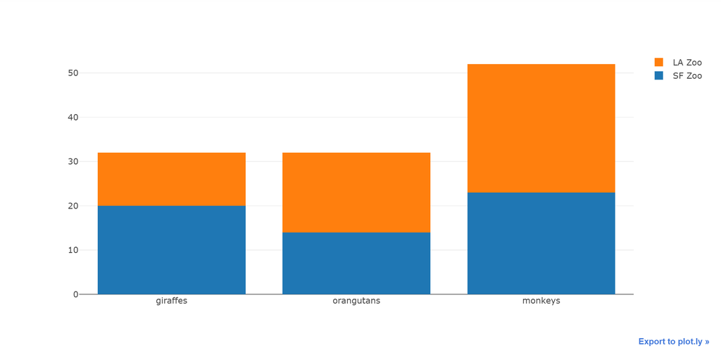

Note that the only difference in code for a grouped and stacked chart is the barmode parameter which is set to either 'group' or 'stack'.

#### Exercise

Create a grouped bar chart with the following data:

- x is type of employee in a company and x = ['Full-Time','Intern','Contractor']
- y_Corp_A is the count of employees in Company A and y_Corp_A = [345,17,43]
- y_Corp_B is the count of employees in Company B and y_Corp_B = [568,6,27]

Create separate traces - one using x and y_Corp_A and the other using x and y_Corp_B. Refer to the example code above to create your plot.

```python
# Enter code to solve above exercise
```

```
# Crete data
x = ['Full-Time','Intern','Contractor']
y_Corp_A = [345,17,43]
y_Corp_B = [568,6,27]

# Create trace 1 for Corp_A
trace1 = go.Bar(
    x=x,
    y=y_Corp_A,
    name='Company A'
)

# Create trace 2 for Corp_B
trace2 = go.Bar(
    x=x,
    y=y_Corp_B,
    name='Company B'
)

# Create data object with both traces
data = [trace1, trace2]

# Create layout object with barmode set to group
layout = go.Layout(
    barmode='group'
)

# Create figure object and visualize plot
fig = go.Figure(data=data, layout=layout)
ofl.iplot(fig, filename='grouped-bar')
```

#### Formatting a bar chart

The bar chart can be customized:

- to show different text labels upon hover or always-shown labels - 'text' and 'textposition' parameters.
- individual bars can be emphasized with different color - Inside the marker dictionary, use 'color' as one of the keys.
- transparency can be added to the bar colors - use the 'opacity' parameter and set value anywhere between 0 and 1, i.e. percentage upto 100.

**Custom Text Labels** Assume that in above giraffes, orangutans and monkeys example, we would like to convey that the Giraffes were imported from Africa, the Orangutans were bought in from Asia and the Monkeys were bought in from South America. We can show this as text. By default you can see that labels are displayed upon hovering. If we use the 'textposition' parameter, we can make sure labels always show and we can decide where the labels are to be positioned.

The syntax to do each of the above is given below:

```
# Syntax to set custom hover text
data = [go.Bar(
            x=['giraffes', 'orangutans', 'monkeys'],
            y=[20, 14, 23],
            text=['Africa','Asia','South America']
    )]

ofl.iplot(data, filename='basic-bar')

# Output
```

[figure not shown]

```
# Syntax to set label at specific position as always showing
data = [go.Bar(
            x=['giraffes', 'orangutans', 'monkeys'],
            y=[20, 14, 23],
            text=['Africa','Asia','South America'],
            textposition='auto'
    )]

ofl.iplot(data, filename='basic-bar')

# Output
```

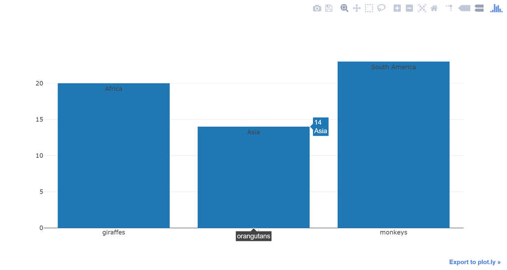

**Custom Bar Colors** Now let us say we want to color giraffes with 'yellow', orangutans as 'orange' and monkeys as 'brown' we can do so using the color parameter in the marker dictionary.

```
# Setting color to each bar
data = [go.Bar(
            x=['giraffes', 'orangutans', 'monkeys'],
            y=[20, 14, 23],
            marker=dict(
            color=['yellow','orange','brown'])
    )]

ofl.iplot(data, filename='basic-bar')

# Output
```

[figure not shown]

```
# You can also use rgba notation for colors - red, green, blue, alpha. Here alpha is opacity of the color
data = [go.Bar(
            x=['giraffes', 'orangutans', 'monkeys'],
            y=[20, 14, 23],
            marker=dict(
            color=['rgba(255,255,0,0.75)','rgba(255,165,0,0.7)','rgba(165,42,42,0.7)'])
    )]

ofl.iplot(data, filename='basic-bar')

# Output
```

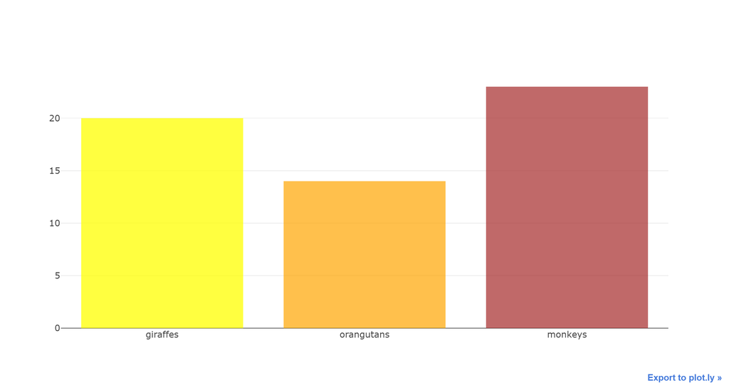

**Custom Overall Opacity**

We can also set overall color opacity for all bars using the opacity parameter.

```
# Refer to the opacity parameter in marker dictionary
data = [go.Bar(
            x=['giraffes', 'orangutans', 'monkeys'],
            y=[20, 14, 23],
            marker=dict(
            color=['yellow','orange','brown']),
            opacity=0.75
    )]

ofl.iplot(data, filename='basic-bar')

# Output
```

[figure not shown]

#### Exercise

Use the same bar chart as constructed in the above exercise you have completed for group bar chart. Refer to the data as below:

- x is type of employee in a company and x = ['Full-Time','Intern','Contractor']
- y_Corp_A is the count of employees in Company A and y_Corp_A = [345,17,43]
- y_Corp_B is the count of employees in Company B and y_Corp_B = [568,6,27]

In this bar chart chart,

- add custom hover labels as 'medium-pay','low-pay' and 'high-pay' for Full-Time, Intern and Contractors respectively.
- Color the Full-Time stack as Red for Corp_A and Green bars for Corp_B, the other bars of Corp_A can take blue as color and other bars of Corp_B can take orange as color, with an overall opacity of 60% (i.e., opacity=0.6).

```python
# Enter code to solve above exercise
```

```
# Crete data
x = ['Full-Time','Intern','Contractor']
y_Corp_A = [345,17,43]
y_Corp_B = [568,6,27]

# Create trace 1 for Corp_A
trace1 = go.Bar(
    x=x,
    y=y_Corp_A,
    text=['medium-pay','low-pay','high-pay'],
    name='Company A',
    marker=dict(
    color=['red','blue','blue']),
    opacity=0.6
)

# Create trace 2 for Corp_B
trace2 = go.Bar(
    x=x,
    y=y_Corp_B,
    text=['medium-pay','low-pay','high-pay'],
    name='Company B',
    marker=dict(
    color=['green','orange','orange']),
    opacity=0.6
)

# Create data object with both traces
data = [trace1, trace2]

# Create layout object with barmode set to group
layout = go.Layout(
    barmode='group'
)

# Create figure object and visualize plot
fig = go.Figure(data=data, layout=layout)
ofl.iplot(fig, filename='grouped-bar')
```

### Pie charts

Pie charts are used to showcase proportions among a total as a percentage. Pie charts are relatively easy to create. We define 'labels' as a list of categories that need to be on the pie chart and a list of equal size with 'values', which define the quantum of contribution of each category to the whole pie. We then create the 'Pie' plot object using the labels and the values defined.

```
# Creating labels
labels = ['Oxygen','Hydrogen','Carbon_Dioxide','Nitrogen']

# Creating values
values = [4500,2500,1053,500]

# Creating the Pie plot object using the labels and values
trace = go.Pie(labels=labels, values=values)

# Visualizing the plot
ofl.iplot([trace], filename='basic_pie_chart')

# Output
```

[figure not shown]

You can also stylize the pie chart with multiple customization options -

```
# Creating labels and values
labels = ['Oxygen','Hydrogen','Carbon_Dioxide','Nitrogen']
values = [4500,2500,1053,500]

# Parameters which can customize - hoverinfo, textinfo, within markers object there is color, line attributes
# Also note that color can be input using hex code as well
trace = go.Pie(labels=labels, values=values,
               hoverinfo='label+percent', textinfo='percent+label',
               textfont=dict(size=20),
               marker=dict(colors=['#FEBFB3', '#E1396C', '#96D38C', '#D0F9B1'],
                           line=dict(color='#000000', width=2)))

ofl.iplot([trace], filename='styled_pie_chart')

# Output
```

[figure not shown]

#### Donuts and Pie-subplots

A donut chart can also be created using the pie chart. The idea is to create a 'hole' on the pie chart. A parameter called hole is available in the definition of data object. The hole parameter takes a value between 0 and 1, which is nothing but percentage of the total pie chart that needs to be covered with the hole, starting from the center.

```
# Dictionary style definition of figure object
fig = {

  # key is data and value is a list of objects - one for each data trace
  "data": [
    {
      # defining values
      "values": [16, 15, 12, 6, 5, 4, 42],

      # defining labels
      "labels": ["US","China","European Union","Russian Federation","Brazil","India","Rest of World"],

      # defining domain - the position of this subplot starts from 0 and occupies first 48% of x axis
      "domain": {"x": [0, .48]},

      # Name of the data object
      "name": "GHG Emissions",

      # Information to be displayed on hover
      "hoverinfo":"label+percent+name",

      # hole which creates the donut
      "hole": .4,

      # type of chart is defined here
      "type": "pie"
    },
    {
      "values": [27, 11, 25, 8, 1, 3, 25],
      "labels": ["US","China","European Union","Russian Federation","Brazil","India","Rest of World"],
      "text":["CO2"],
      "textposition":"inside",

      # defining domain - the position of this subplot starts from 0.52 and occupies remaining 48% of x axis, 4% is padding
      "domain": {"x": [.52, 1]},
      "name": "CO2 Emissions",
      "hoverinfo":"label+percent+name",
      "hole": .4,
      "type": "pie"
    }],
  "layout": {
        "title":"Global Emissions 1990-2011",
        "annotations": [
            {
                "font": {"size": 20},
                "showarrow": False,
                "text": "GHG",
                "x": 0.20,
                "y": 0.5
            },
            {
                "font": {"size": 20},
                "showarrow": False,
                "text": "CO2",
                "x": 0.8,
                "y": 0.5
            }
        ]
    }
}

ofl.iplot(fig, filename='donut')

# Output
```

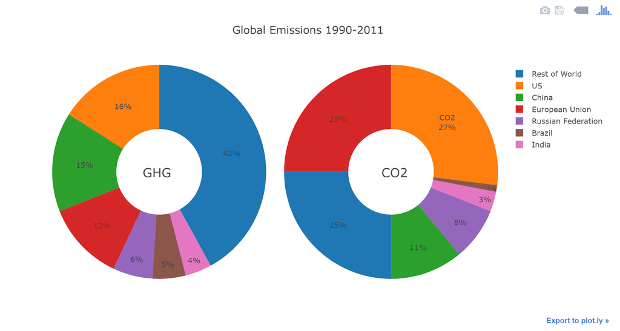

#### Exercise

Create a donut pie sub-plot comparing the proportion of employees in Corp_A and Corp_B. Refer to the data:

- x is type of employee in a company and x = ['Full-Time','Intern','Contractor']
- y_Corp_A is the count of employees in Company A and y_Corp_A = [345,17,43]
- y_Corp_B is the count of employees in Company B and y_Corp_B = [568,6,27]

You may use the dictionary style definition of figure object to create the subplots. Use 4% standard padding between both sub-plots. Refer to above example code, it has 4% padding.

```python
# Enter code to solve above exercise
```

```
# Dictionary style definition of figure object
fig = {

  # key is data and value is a list of objects - one for each data trace
  "data": [
    {
      # defining values
      "values": [345,17,43],

      # defining labels
      "labels": ["Full-Time","Intern","Contractor"],

      # defining domain - the position of this subplot starts from 0 and occupies first 48% of x axis
      "domain": {"x": [0, .48]},

      # Name of the data object
      "name": "Corp_A proportion",

      # Information to be displayed on hover
      "hoverinfo":"label+percent+name",

      "hole":0.3,

      # type of chart is defined here
      "type": "pie"
    },
    {
      "values": [568,6,27],
      "labels": ["Full-Time","Intern","Contractor"],
      # defining domain - the position of this subplot starts from 0.52 and occupies remaining 48% of x axis, 4% is padding
      "domain": {"x": [.52, 1]},
      "name": "Corp_B proportion",
      "hoverinfo":"label+percent+name",
      "hole":0.3,
      "type": "pie"
    }],
  "layout": {
        "title":"Proportion of Human Resources",
        "annotations": [
            {
                "font": {"size": 20},
                "showarrow": False,
                "text": "Corp A",
                "x": 0.194,
                "y": 0.5
            },
            {
                "font": {"size": 20},
                "showarrow": False,
                "text": "Corp B",
                "x": 0.808,
                "y": 0.5
            }
        ]
    }
}
ofl.iplot(fig, filename='donut')
```

### Bubble charts

The bubble chart is a specialized scatter plot. In a typical 2-dimensional scatter plot, observations have 2 dimensions/features - x and y. The bubble chart has the capability to present multiple dimensions/features of observations in a single plot. The typical observations of a scatter plot shown in the form of dots or tiny circles can be increased to show variable sized circles depicting each observation. The size of each circle may be determined by a 'third feature' of the observation. The color of the circle may be determined by the 'fourth feature' of the observation or data set. The plot would showcase multiple sized circles scattered across the X-Y coordinate system. This is called a Bubble chart.

A bubble chart can be created from a scatter plot object by modifying the 'marker' dictionary. The parameters that can be modified to create a bubble chart are:

1. size - this parameter/key can take a list of values. The list should be the same length as the number of observations. It determines the size of each bubble.
2. color - this parameter/key can take a list of values. The list should be the same length as the number of observations. It determines the color of each bubble.

**Note: It is important to observe that the fourth feature that can be represented using color of the bubble needs to be a categorical variable. Also, the third feature which is represented by size of bubble is generally numerical in nature.**

An example bubble chart code is:

```
# Create scatter plot object, but add color and size parameters to the 'marker' dictionary
trace0 = go.Scatter(
    x=[1, 2, 3, 4],
    y=[10, 11, 12, 13],
    mode='markers',
    marker=dict(
        color=['rgb(93, 164, 214)', 'rgb(255, 144, 14)',
               'rgb(44, 160, 101)', 'rgb(255, 65, 54)'],
        opacity=[1, 0.8, 0.6, 0.4],
        size=[40, 60, 80, 100],
    )
)

# Visualize plot
ofl.iplot([trace0], filename='bubblechart-color')

# Output
```

[figure not shown]

Another example with overlapping bubbles:

```
# Create scatter plot object, but add color and size parameters to the 'marker' dictionary
trace0 = go.Scatter(
    x=[1, 1.5, 1.48, 1.75, 1.85, 1.95, 2, 2.25, 2.25, 2.28, 2.5, 2.5, 3],
    y=[12, 12, 12.3, 13, 12.1, 12.2, 12, 11.5, 12.5, 12.25, 11.2, 11.5, 13.5],
    mode='markers',
    marker=dict(
        color=['rgb(93, 164, 214)', 'rgb(255, 144, 14)',
               'rgb(44, 160, 101)', 'rgb(255, 65, 54)',
               'rgb(52, 63, 123)','rgb(135, 12, 73)',
               'rgb(65, 108, 25)', 'rgb(125, 230, 20)',
               'rgb(56, 35, 222)','rgb(130,30,30)',
               'rgb(46, 123, 123)','rgb(124, 24, 1)',
               'rgb(235, 141, 55)'],
        size=[20, 50, 35, 40, 45, 40, 45, 50, 55, 60, 40, 60, 10],
    )
)

# Visualize plot
ofl.iplot([trace0], filename='bubblechart-overlapping')

# Output
```

[figure not shown]

#### Exercise

Create a bubble chart with the following data:

- x is 10 random numbers chosen within a range of 10 and 25. They can take floating point values.
- y is 10 random numbers chosen within a range of 5 and 20. They can also take floating point values.
- z is third feature size, a list of 10 sizes, random integers between 20 and 65.

You may add any colors to the bubbles as you want. It is optional.

```python
# Enter code to solve above exercise
```

```
import numpy as np

# Creating data
x=[]
y=[]
z=[]
for i in range(0,10):
    x.append(np.random.randint(10,26)+np.random.rand())
    y.append(np.random.randint(5,21)+np.random.rand())
    z.append(np.random.randint(20,66))

# Creating trace
trace_1 = go.Scatter(
    x=x,
    y=y,
    mode='markers',
    marker=dict(
        color=['rgb(93, 164, 214)', 'rgb(255, 144, 14)',
               'rgb(44, 160, 101)', 'rgb(255, 65, 54)',
               'rgb(52, 63, 123)','rgb(135, 12, 73)',
               'rgb(65, 108, 25)', 'rgb(125, 230, 20)',
               'rgb(56, 35, 222)','rgb(130,30,30)'],
        size=z,
    )
)

# Visualizing the plot
ofl.iplot([trace_1], filename='bubblechart-random')
```

### Gauge charts

A gauge chart is visually similar to a meter which is usually used to visually represent a certain 'rating' or 'current state'. We can create a semi-circular gauge chart from a donut chart, by dividing the donut into specific segments and then making the lower half of the donut to be the same color as the background.

Although it is an interesting and appealing visualization, it is slightly laborius to construct. In order to construct a good looking gauge/meter chart, we need 3 pieces:

- base chart - which contains the segmented divisions
- meter chart - which contains the segment colors and labels
- dial - the dial arm which points at one of the segments of the meter

All these 3 components are then overlapped with a donut chart in order to create the gauge meter chart. An example code is given below:

```
# A rotated base chart creation
base_chart = {
    "values": [40, 10, 10, 10, 10, 10, 10],
    "labels": ["-", "0", "20", "40", "60", "80", "100"],
    "domain": {"x": [0, .48]},
    "marker": {
        "colors": [
            'rgb(255, 255, 255)',
            'rgb(255, 255, 255)',
            'rgb(255, 255, 255)',
            'rgb(255, 255, 255)',
            'rgb(255, 255, 255)',
            'rgb(255, 255, 255)',
            'rgb(255, 255, 255)'
        ],
        "line": {
            "width": 1
        }
    },
    "name": "Gauge",
    "hole": .4,
    "type": "pie",
    "direction": "clockwise",
    "rotation": 108,
    "showlegend": False,
    "hoverinfo": "none",
    "textinfo": "label",
    "textposition": "outside"
}

# Meter chart creation
meter_chart = {
    "values": [50, 10, 10, 10, 10, 10],
    "labels": ["Log Level", "Debug", "Info", "Warn", "Error", "Fatal"],
    "marker": {
        'colors': [
            'rgb(255, 255, 255)',
            'rgb(232,226,202)',
            'rgb(226,210,172)',
            'rgb(223,189,139)',
            'rgb(223,162,103)',
            'rgb(226,126,64)'
        ]
    },
    "domain": {"x": [0, 0.48]},
    "name": "Gauge",
    "hole": .3,
    "type": "pie",
    "direction": "clockwise",
    "rotation": 90,
    "showlegend": False,
    "textinfo": "label",
    "textposition": "inside",
    "hoverinfo": "none"
}

# Creating dial within layout
layout = {
    'xaxis': {
        'showticklabels': False,
        'showgrid': False,
        'zeroline': False,
    },
    'yaxis': {
        'showticklabels': False,
        'showgrid': False,
        'zeroline': False,
    },

    # Creating the dial using a triangle shape
    'shapes': [
        {
            'type': 'path',
            'path': 'M 0.235 0.5 L 0.24 0.65 L 0.245 0.5 Z',
            'fillcolor': 'rgba(44, 160, 101, 0.5)',
            'line': {
                'width': 0.5
            },
            'xref': 'paper',
            'yref': 'paper'
        }
    ],
    'annotations': [
        {
            'xref': 'paper',
            'yref': 'paper',
            'x': 0.23,
            'y': 0.45,
            'text': '50',
            'showarrow': False
        }
    ]
}

# we don't want the boundary now
base_chart['marker']['line']['width'] = 0

fig = {"data": [base_chart, meter_chart],
       "layout": layout}
ofl.iplot(fig, filename='gauge-meter-chart')

# Output
```

[figure not shown]

```python
# End of lesson. No Exercise
```